# Tutorial for `MDRefine` - 1b

In these notebooks we are going to perform several different refinements of MD-generated trajectories by employing the package `MDRefine`. In this way, we believe the usage of `MDRefine` will become clear and easy to emulate for your own case of interest.

We remind you to have a look at our paper https://arxiv.org/pdf/2411.07798 and at the documentation https://www.bussilab.org/doc-MDRefine/MDRefine/index.html.

Required assistance may be opened at https://github.com/bussilab/MDRefine/issues.

```python
# install matplotlib and other dependencies
!pip install -r requirements.txt
```

```python
import numpy as np
import jax.numpy as jnp
import pandas
import matplotlib
import matplotlib.pyplot as plt
from IPython.display import clear_output
```

```python
# import from parent directory
import sys
sys.path.insert(0, '../')

import MDRefine

print("I will use the MDRefine version installed at", MDRefine.__file__)
```

```
I will use the MDRefine version installed at /home/runner/work/MDRefine/MDRefine/Examples/../MDRefine/__init__.py
```

```python
from MDRefine import load_data, minimizer, split_dataset, hyper_minimizer, MDRefinement, unwrap_dict
```

## 2. Force-field refinement

In this section, we are going to reproduce part of the results presented in *I. Gilardoni et al., "Boosting ensemble refinement with transferable force-field corrections: synergistic optimization for molecular simulations", J. Phys. Chem. Letters 15.5 (2024)* https://pubs.acs.org/doi/full/10.1021/acs.jpclett.3c03423.

In particular, we will focus on fitting a force-field correction to refine structural ensembles of RNA oligomers.

```python
%%bash

if [ ! -d "DATA" ]; then
    curl -O https://zenodo.org/records/14956459/files/DATA.zip

    unzip DATA.zip
    rm -r DATA.zip
fi
```

### a. Load data

Load experimental data, observables and forward model as previously done. Also, load force-field correction terms and corresponding functional form.

```python
infos = {}

# Define global properties, valid for all the systems:
infos['global'] = {
    'path_directory': 'DATA',
    'system_names': ['AAAA','CCCC','GACC','UUUU','UCAAUC'],

    # Then, define properties which are specific of each system, like experimental data and observables
    # If some properties are the same for all the systems, you can store them just once in infos['global']
    'g_exp': ['backbone1_gamma_3J', 'backbone2_beta_epsilon_3J', 'sugar_3J', 'NOEs', ('uNOEs','<')],
    'forward_qs': ['backbone1_gamma','backbone2_beta_epsilon','sugar'],
    'obs': ['NOEs','uNOEs'],
    'forward_coeffs': 'original_fm_coeffs'}

# Select the stride for the frames
stride = 10  # 00
```

```python
def forward_model_fun(fm_coeffs, forward_qs, selected_obs=None):

    # 1. compute the cosine (which is the quantity you need in the forward model;
    # you could do this just once before loading data)
    forward_qs_cos = {}

    for type_name in forward_qs.keys():
        forward_qs_cos[type_name] = np.cos(forward_qs[type_name])

    # if you have selected_obs, compute only the corresponding observables
    if selected_obs is not None:
        for type_name in forward_qs.keys():
            forward_qs_cos[type_name] = forward_qs_cos[type_name][:,selected_obs[type_name+'_3J']]

    # 2. compute observables (forward_qs_out) through forward model
    forward_qs_out = {
        'backbone1_gamma_3J': fm_coeffs[0]*forward_qs_cos['backbone1_gamma']**2 + fm_coeffs[1]*forward_qs_cos['backbone1_gamma'] + fm_coeffs[2],
        'backbone2_beta_epsilon_3J': fm_coeffs[3]*forward_qs_cos['backbone2_beta_epsilon']**2 + fm_coeffs[4]*forward_qs_cos['backbone2_beta_epsilon'] + fm_coeffs[5],
        'sugar_3J': fm_coeffs[6]*forward_qs_cos['sugar']**2 + fm_coeffs[7]*forward_qs_cos['sugar'] + fm_coeffs[8] }

    return forward_qs_out
```

```python
infos['global']['forward_model'] = forward_model_fun
```

Now, let's define the force-field correction terms: we selected (for each molecule) \begin{equation} \beta\Delta V = \sum_{i}\Bigl[\phi_1\cos\alpha_i + \phi_2\sin\alpha_i + \phi_3 \cos \zeta_i + \phi_4 \sin\zeta_i\Bigr] \end{equation} where the sum is over the residues. We can also consider this correction on $\alpha$ dihedral angles only (choose among the following two notebook cells).

Since Numpy arrays `ff_terms` have columns

`['sinalpha[0]', 'sinalpha[1]', 'sinalpha[2]', 'sinzeta[0]', 'sinzeta[1]', 'sinzeta[2]', 'cosalpha[0]', 'cosalpha[1]', 'cosalpha[2]', 'coszeta[0]', 'coszeta[1]', 'coszeta[2]']`,

these two corrections are defined by the following functions (use `jax.numpy`).

```python
# correction on alpha dihedral angles only
def ff_correction_tetramers(pars, f):
    out = jnp.matmul(pars, (f[:,[0,6]]+f[:,[1,7]]+f[:,[2,8]]).T)
    return out

def ff_correction_hexamers(pars, f):
    out = jnp.matmul(pars, (f[:,[0,10]]+f[:,[1,11]]+f[:,[2,12]]+f[:,[3,13]]+f[:,[4,14]]).T)
    return out

infos['global']['ff_correction'] = ff_correction_tetramers
infos['UCAAUC'] = {'ff_correction': ff_correction_hexamers}

infos['global']['names_ff_pars'] = ['sin alpha', 'cos alpha']
```

```python
# correction on alpha, zeta dihedral angles
def ff_correction_tetramers(pars, f):
    out = jnp.matmul(pars, (f[:,[0,6,3,9]]+f[:,[1,7,4,10]]+f[:,[2,8,5,11]]).T)
    return out

def ff_correction_hexamers(pars, f):
    out = jnp.matmul(pars, (f[:,[0,10,5,15]]+f[:,[1,11,6,16]]+f[:,[2,12,7,17]]+f[:,[3,13,8,18]]+f[:,[4,14,9,19]]).T)
    return out

infos['global']['ff_correction'] = ff_correction_tetramers
infos['UCAAUC'] = {'ff_correction': ff_correction_hexamers}

infos['global']['names_ff_pars'] = ['sin alpha', 'cos alpha', 'sin zeta', 'cos zeta']
```

```python
# split frames based on "demuxing" (continuous trajectories from temperature replica exchange)
for name_sys in ['AAAA', 'CCCC', 'GACC', 'UUUU']:  # except hexamers
    infos[name_sys] = {'n_temp_replica': 6}
```

```python
data = load_data(infos, stride=stride)
```

```
loading data from directory...
loading  AAAA
loading  CCCC
```

```
loading  GACC
```

```
loading  UUUU
loading  UCAAUC
```

```
done
```

Now, let's define the **regularization** for the force-field refinement. You can choose among `plain l2` (acting on the coefficients) or `KL divergence` (acting directly on the ensemble).

```python
regularization = {'force_field_reg': 'KL divergence'}
```

### b. Minimize the loss function and analyse the results

for a single choice of the hyper-parameter $\beta$

Use function `minimizer` with selected data, regularization and beta as input

```python
Result = minimizer(data, regularization=regularization, beta=100)
```

[output not shown]

```python
vars(Result).keys()
```

```
dict_keys(['loss', 'pars', 'mini', 'intermediates', 'time', 'reg_ff', 'av_g', 'chi2', 'weights_new', 'logZ_new'])
```

Besides the same quantities already described in the previous notebook `Tutorial_1.ipynb` (such as: **av_g**, **chi2**, **weights_new**, **logZ_new**), we now have:

- optimal force-field correction parameters **pars**;
- output of minimization **mini**;
- value of force-field regularization **reg_ff**.

```python
Result.pars
```

```
array([ 0.70782667, -1.35686344,  0.19536056, -0.15471603])
```

```python
Result.mini
```

```
  message: Optimization terminated successfully.
  success: True
   status: 0
      fun: 4282.5221094030485
        x: [ 7.078e-01 -1.357e+00  1.954e-01 -1.547e-01]
      nit: 19
      jac: [-2.047e-06  6.499e-06 -1.108e-04 -6.280e-05]
 hess_inv: [[ 1.553e-04 -3.918e-05 -8.916e-05 -4.702e-06]
            [-3.918e-05  1.996e-04 -4.084e-07  7.112e-05]
            [-8.916e-05 -4.084e-07  1.300e-04 -2.138e-05]
            [-4.702e-06  7.112e-05 -2.138e-05  1.990e-04]]
     nfev: 27
     njev: 27
```

```python
Result.reg_ff
```

```
{'AAAA': Array(0.64664231, dtype=float64),
 'CCCC': Array(0.945109, dtype=float64),
 'GACC': Array(0.45278288, dtype=float64),
 'UUUU': Array(0.74349203, dtype=float64),
 'UCAAUC': Array(1.40301772, dtype=float64)}
```

### c. Determine optimal hyper parameter $\beta$ through cross validation (scan over $\beta$)

Split the data set with `split_dataset` and minimize the loss function with `minimizer` over different values of the hyperparamter $\beta$ in logarithmic scale.

```python
data_train, data_valid, valid_obs, valid_frames = split_dataset(data, random_state=2, replica_infos=infos)
```

```
Input random_state employed both for observables and frames
```

```python
log10_betas = np.arange(-2, 7, 0.5)

Results = {}

for log10_beta in log10_betas:
    print(log10_beta)

    beta = 10**np.float64(log10_beta)
    Results[log10_beta] = minimizer(data_train, regularization=regularization, beta=beta, data_valid=data_valid)

    print(Results[log10_beta].loss)

    clear_output()
```

```python
# Check the convergence of the minimization
print([Results[log10_beta].mini.success for log10_beta in log10_betas])
```

```
[True, True, True, True, True, True, True, True, True, True, True, True, True, True, True, False, True, True]
```

Plot the loss function in training and validation, refined coefficients of the force-field correction, the $\chi^2$ and the regularization as a function of the hyperparameter $\beta$.

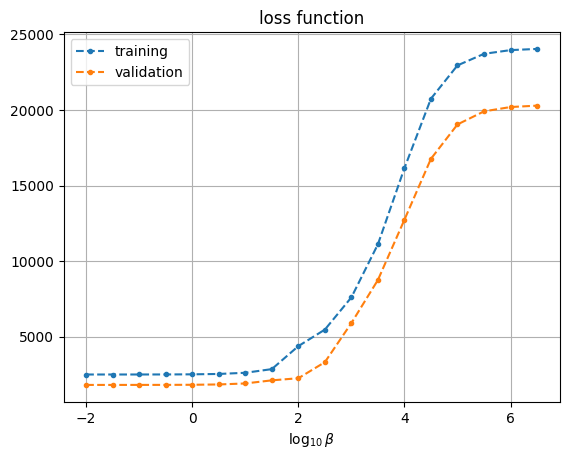

```python
loss = [Results[log10_beta].loss for log10_beta in log10_betas]
loss_valid = [Results[log10_beta].loss_valid for log10_beta in log10_betas]

plt.title('loss function')
plt.plot(log10_betas, loss, '.--', label = 'training')
plt.plot(log10_betas, loss_valid, '.--', label = 'validation')
plt.xlabel(r'$\log_{10}\beta$')
plt.legend()
plt.grid()
```

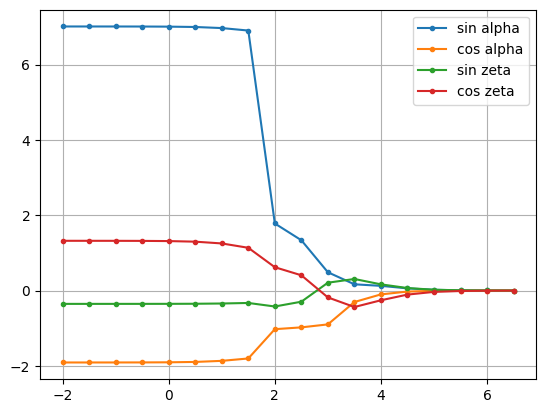

```python
coeffs = np.array([Results[log10_beta].pars for log10_beta in log10_betas]).T

for i in range(len(coeffs)):
    plt.plot(log10_betas, coeffs[i], '.-', label=data.properties.names_ff_pars[i])

plt.legend()
plt.grid()
```

```python
chi2s = [np.sum(unwrap_dict(Results[log10_beta].chi2)) for log10_beta in log10_betas]
n_obs_train = data_train.properties.tot_n_experiments(data_train)

red_chi2s = np.array(chi2s)/n_obs_train

chi2s_valid1 = [np.sum(unwrap_dict(Results[log10_beta].chi2_valid)) for log10_beta in log10_betas] # .chi2_valid
red_ch2s_valid1 = np.array(chi2s_valid1)/n_obs_train

chi2s_valid2 = [np.sum(unwrap_dict(Results[log10_beta].chi2_new_obs)) for log10_beta in log10_betas] # .chi2_valid
n_obs_valid = len(unwrap_dict(valid_obs))

red_chi2s_valid2 = np.array(chi2s_valid2)/n_obs_valid
```

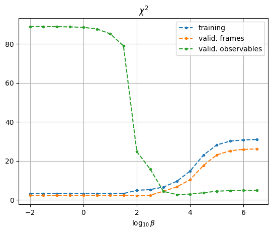

```python
plt.plot(log10_betas, red_chi2s, '.--', label='training')
plt.plot(log10_betas, red_ch2s_valid1, '.--', label='valid. frames')
plt.plot(log10_betas, red_chi2s_valid2, '.--', label='valid. observables')

plt.legend()
plt.title('$\chi^2$')
plt.xlabel(r'$\log_{10}\beta$')
plt.grid()
```

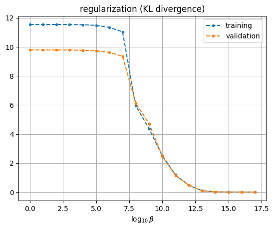

```python
D_KL_train = [np.sum(unwrap_dict(Results[log10_beta].reg_ff)) for log10_beta in log10_betas]
D_KL_valid = [np.sum(unwrap_dict(Results[log10_beta].reg_ff_valid)) for log10_beta in log10_betas]

plt.title('regularization (KL divergence)')
plt.plot(D_KL_train, '.--', label = 'training')
plt.plot(D_KL_valid, '.--', label = 'validation')
plt.xlabel(r'$\log_{10}\beta$')
plt.legend()
plt.grid()
```

### d. Determine optimal hyper parameter $\beta$ through cross validation (automatic optimization)

Let's use `hyper_minimizer` to get the optimal value of the hyperparameter $\beta$. Here, `random_states` can be either a list of values or an integer; if it is an integer, you will take values in `np.arange(random_states)`.

Let's take the same `random_state` used for the scan, so that we can compare the results of `hyper_minimizer` with the previous plot of the $\chi^2$.

To validate the efficiency of the convergence, start from a high $\beta$ value.

```python
starting_beta = 1e5

mini = hyper_minimizer(data, regularization=regularization, starting_beta=starting_beta, random_states=[2])
```

[output not shown]

```
log10 hyperpars:  [('beta', np.float64(4.999999999999999))]
```

```
av. chi2:  35762.88492108806
av. gradient:  [10595.93437625]

log10 hyperpars:  [('beta', np.float64(3.999999999999999))]
```

```
av. chi2:  16062.061412466677
av. gradient:  [18403.1567724]

log10 hyperpars:  [('beta', np.float64(-8.881784197001252e-16))]
```

```
av. chi2:  3590.309887087413
av. gradient:  [0.42322092]
```

```python
mini
```

```
      message: CONVERGENCE: NORM OF PROJECTED GRADIENT <= PGTOL
      success: True
       status: 0
          fun: 3590.309887087413
            x: [-8.882e-16]
          nit: 1
          jac: [ 4.232e-01]
         nfev: 3
         njev: 3
     hess_inv: <1x1 LbfgsInvHessProduct with dtype=float64>
 intermediate: <MDRefine.hyperminimizer.hyper_minimizer.<locals>.hyper_intermediate_class object at 0x7f9fde9cc200>
```

The `intermediate` attribute shows the intermediate steps of the hyperminimization (i.e., the minimization of the $\chi^2$ to search for the optimal hyperparameters)

```python
vars(mini.intermediate)
```

```
{'av_chi2': Array([35762.88492109, 16062.06141247,  3590.30988709], dtype=float64),
 'av_gradient': Array([[1.05959344e+04],
        [1.84031568e+04],
        [4.23220923e-01]], dtype=float64),
 'log10_hyperpars': Array([[ 5.0000000e+00],
        [ 4.0000000e+00],
        [-8.8817842e-16]], dtype=float64)}
```

With the default value `which_set = 'validating'` (namely, minimize the $\chi^2$ on left-out frames but same observables), $\beta$ stops at low values due to the plateau in the figure, and we found $\beta = 1$.

Let's try also with `which_set = 'validation'` (left-out observables).

```python
mini2 = hyper_minimizer(data, regularization=regularization, starting_beta=starting_beta, random_states=[2], which_set='validation')
```

[output not shown]

```
log10 hyperpars:  [('beta', np.float64(4.999999999999999))]
```

```
av. chi2:  35762.88492108806
av. gradient:  [10595.93437625]

log10 hyperpars:  [('beta', np.float64(3.999999999999999))]
```

```
av. chi2:  16062.061412466677
av. gradient:  [18403.1567724]

log10 hyperpars:  [('beta', np.float64(-8.881784197001252e-16))]
```

```
av. chi2:  3590.309887087413
av. gradient:  [0.42322092]
```

```python
mini2
```

```
      message: CONVERGENCE: NORM OF PROJECTED GRADIENT <= PGTOL
      success: True
       status: 0
          fun: 3590.309887087413
            x: [-8.882e-16]
          nit: 1
          jac: [ 4.232e-01]
         nfev: 3
         njev: 3
     hess_inv: <1x1 LbfgsInvHessProduct with dtype=float64>
 intermediate: <MDRefine.hyperminimizer.hyper_minimizer.<locals>.hyper_intermediate_class object at 0x7f9fd47abcb0>
```

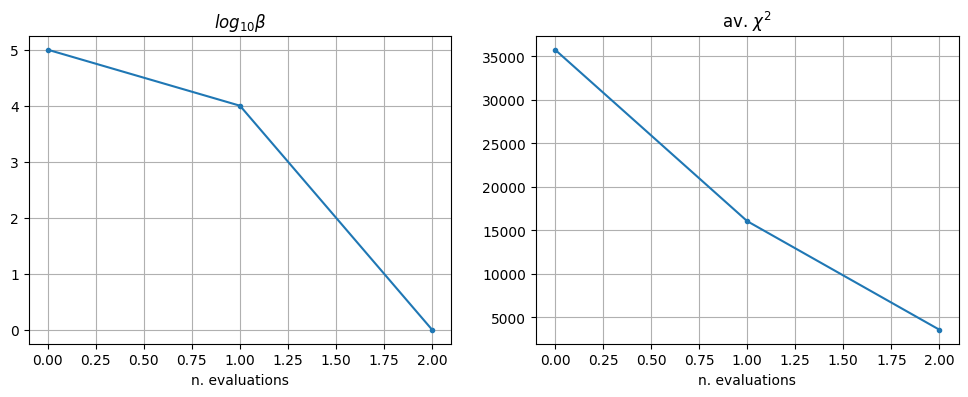

```python
fig, axs = plt.subplots(1, 2, figsize=(12, 4))

axs[0].plot(mini2.intermediate.log10_hyperpars, '.-')
axs[0].set_title(r'$log_{10} \beta$')
axs[0].set_xlabel('n. evaluations')
axs[0].grid()

axs[1].plot(mini2.intermediate.av_chi2, '.-')
axs[1].set_title(r'av. $\chi^2$')
axs[1].set_xlabel('n. evaluations')
axs[1].grid()
```

```python
mini = hyper_minimizer(data, regularization=regularization, starting_beta=starting_beta, random_states=2)
```

[output not shown]

```
Input random_state employed both for observables and frames
```

```
log10 hyperpars:  [('beta', np.float64(4.999999999999999))]
```

```
av. chi2:  35723.6734286572
av. gradient:  [10391.82897124]

log10 hyperpars:  [('beta', np.float64(3.999999999999999))]
```

```
av. chi2:  15892.243971127999
av. gradient:  [19637.9276208]

log10 hyperpars:  [('beta', np.float64(-8.881784197001252e-16))]
```

```
av. chi2:  16700.237123996158
av. gradient:  [2012.34164902]

log10 hyperpars:  [('beta', np.float64(-1.2007546354764334))]
```

```
av. chi2:  15919.416606646608
av. gradient:  [114.75135025]
```

```python
print(mini)

print('\n\nintermediate steps:')
print(vars(mini.intermediate))
```

```
      message: CONVERGENCE: RELATIVE REDUCTION OF F <= FACTR*EPSMCH
      success: True
       status: 0
          fun: 15919.416606646608
            x: [-1.201e+00]
          nit: 2
          jac: [ 1.148e+02]
         nfev: 4
         njev: 4
     hess_inv: <1x1 LbfgsInvHessProduct with dtype=float64>
 intermediate: <MDRefine.hyperminimizer.hyper_minimizer.<locals>.hyper_intermediate_class object at 0x7f9fde627200>


intermediate steps:
{'av_chi2': Array([35723.67342866, 15892.24397113, 16700.237124  , 15919.41660665],      dtype=float64), 'av_gradient': Array([[10391.82897124],
       [19637.9276208 ],
       [ 2012.34164902],
       [  114.75135025]], dtype=float64), 'log10_hyperpars': Array([[ 5.00000000e+00],
       [ 4.00000000e+00],
       [-8.88178420e-16],
       [-1.20075464e+00]], dtype=float64)}
```

```python
opt_beta = 10**mini.x[0]

print(opt_beta)
```

```
0.06298619371476809
```

```python
result = minimizer(data, regularization=regularization, beta=opt_beta)
```

[output not shown]

```python
vars(result)
```

```
{'loss': Array(3850.51394279, dtype=float64),
 'pars': array([ 0.73588997, -1.42174398,  0.2064404 , -0.17941788]),
 'mini':   message: Optimization terminated successfully.
   success: True
    status: 0
       fun: 3850.5139427881527
         x: [ 7.359e-01 -1.422e+00  2.064e-01 -1.794e-01]
       nit: 20
       jac: [ 4.953e-04  2.795e-05 -1.190e-04  6.623e-04]
  hess_inv: [[ 1.365e-04 -3.812e-05 -7.047e-05 -1.655e-05]
             [-3.812e-05  2.053e-04 -9.681e-06  7.333e-05]
             [-7.047e-05 -9.681e-06  1.167e-04 -1.956e-05]
             [-1.655e-05  7.333e-05 -1.956e-05  1.866e-04]]
      nfev: 28
      njev: 28,
 'intermediates': <MDRefine.loss_and_minimizer.intermediates_class at 0x7f9fde4cc0e0>,
 'time': 28.526857137680054,
 'reg_ff': {'AAAA': Array(0.67976714, dtype=float64),
  'CCCC': Array(0.98576302, dtype=float64),
  'GACC': Array(0.4740662, dtype=float64),
  'UUUU': Array(0.79033149, dtype=float64),
  'UCAAUC': Array(1.52992792, dtype=float64)},
 'av_g': {'AAAA': {'backbone1_gamma_3J': Array([2.44899199, 2.3166003 , 1.94809   , 1.7613554 , 1.96274694,
          1.78313189, 2.45627591, 1.83846203], dtype=float64),
   'backbone2_beta_epsilon_3J': Array([7.22761025, 4.26932561, 2.06606798, 6.76199778, 3.7886554 ,
          2.00217386, 5.98385684, 3.50226812, 2.28810129], dtype=float64),
   'sugar_3J': Array([2.56904821, 4.50130122, 9.07647023, 1.11153629, 4.475424  ,
          9.85878703, 1.09948573, 4.37734547, 9.93732879, 4.32367371,
          6.75151263], dtype=float64),
   'NOEs': Array([1.62594475e-03, 6.33027239e-05, 8.54402699e-04, 7.70649699e-04,
          1.37452191e-04, 1.23688320e-04, 1.35982532e-03, 1.13349268e-04,
          2.43679224e-03, 6.94401072e-04, 2.23544705e-03, 1.52581988e-03,
          3.26063422e-04, 3.06735529e-04, 9.49860857e-05, 5.40040239e-04,
          7.21428185e-05, 4.84125097e-04, 4.39112800e-04, 1.90115798e-03,
          4.12549217e-03, 1.63620819e-03, 1.46425933e-04, 1.27816853e-04,
          2.61791902e-04, 5.97547034e-04, 7.04370608e-05, 2.55813997e-04,
          1.89242554e-03, 4.30020876e-04, 8.00791605e-04, 1.46132262e-04,
          3.29546164e-04, 2.74114753e-03, 1.00522880e-04, 9.17216107e-04],      dtype=float64),
   'uNOEs': Array([1.39436642e-05, 3.53204289e-06, 8.76808382e-07, 1.31950881e-07,
          8.18227060e-05, 9.19209789e-06, 2.20869683e-05, 1.74648479e-05,
```

[output cut: 701 more lines]

```
         1.57045960e-04, 3.40455220e-05, 2.37466611e-04, 2.00501803e-03,
         3.74340358e-05, 5.50261794e-03, 3.21006085e-04, 2.72582585e-04,
         1.45954501e-03, 6.90945896e-04, 2.62704107e-03, 6.74304896e-05,
         8.40083368e-04, 1.82608708e-05, 2.34762411e-03, 1.64689739e-04,
         1.48011324e-04, 3.24950554e-03, 5.94506767e-06, 6.59452558e-04,
         1.10308987e-03, 1.08067221e-03, 9.38968990e-04, 1.18485399e-02,
         5.31993129e-05, 2.59663497e-04, 3.35598254e-03, 3.13205106e-03,
         8.40180497e-03, 9.53556471e-04, 1.52764605e-03, 4.02074293e-04],      dtype=float64),
  'UCAAUC': Array([2.07637852e-04, 1.94654074e-04, 1.64083125e-04, ...,
         6.63419402e-04, 3.55102623e-05, 8.44761167e-04], dtype=float64)},
 'logZ_new': {'AAAA': Array(2.91648683, dtype=float64),
  'CCCC': Array(2.85182835, dtype=float64),
  'GACC': Array(3.44085206, dtype=float64),
  'UUUU': Array(2.2984348, dtype=float64),
  'UCAAUC': Array(-0.03568637, dtype=float64)}}
```

This can be automatically done with `MDRefinement` and the output results will be saved in the directory whose default path name is `results`

```python
my_results = MDRefinement(infos, stride=stride, regularization=regularization, starting_beta=starting_beta, random_states=2)
```

```
loading data from directory...
loading  AAAA
loading  CCCC
```

```
loading  GACC
loading  UUUU
```

```
loading  UCAAUC
```

[output not shown]

```
Input random_state employed both for observables and frames
```

```
log10 hyperpars:  [('beta', np.float64(4.999999999999999))]
```

```
av. chi2:  35723.6734286572
av. gradient:  [10391.82897124]

log10 hyperpars:  [('beta', np.float64(3.999999999999999))]
```

```
av. chi2:  15892.243971127999
av. gradient:  [19637.9276208]

log10 hyperpars:  [('beta', np.float64(-8.881784197001252e-16))]
```

```
av. chi2:  16700.237123996158
av. gradient:  [2012.34164902]

log10 hyperpars:  [('beta', np.float64(-1.2007546354764334))]
```

```
av. chi2:  15919.416606646608
av. gradient:  [114.75135025]

optimal hyperparameters: beta: 0.06298619371476809

refinement with optimal hyperparameters...
```

```
done
```

```python
vars(my_results).keys()
```

```
dict_keys(['loss', 'pars', 'mini', 'intermediates', 'time', 'reg_ff', 'av_g', 'chi2', 'weights_new', 'logZ_new', 'optimal_hyperpars', 'hyper_minimization'])
```

```python
vars(my_results.hyper_minimization.intermediate)
```

```
{'av_chi2': Array([35723.67342866, 15892.24397113, 16700.237124  , 15919.41660665],      dtype=float64),
 'av_gradient logbeta': Array([10391.82897124, 19637.9276208 ,  2012.34164902,   114.75135025],      dtype=float64),
 'log10_hyperpars beta': Array([ 5.00000000e+00,  4.00000000e+00, -8.88178420e-16, -1.20075464e+00],      dtype=float64)}
```